# USP654: Data Analysis II

## Dummy Variables

### Liming Wang

### October 30, 2017

# Outline

- Regression with Categorical Independent Variables
   - Testing Differences in Means Among the Included Groups
   - Ordinal Categorical Variable
- Interaction
   - Research questions
   -
   - Simpson's Paradox

# Testing Differences in Means Among the Included Groups

The coefficients are the mean differences to the reference category for the corresponding group. What if we are interested in the difference between LA and SD?

1. Re-estimating the regression model with a different reference category
2. Using a partial F test
3. Testing the significance of a linear combination of coefficients

# Testing Differences in Means Among the Included Groups (1)

```r
catod2 <- californiatod %>% mutate(region = relevel(as.factor(region), ref = 4))
lm(houseval ~ region, data=catod2)  %>% summary
```

```
##
## Call:
## lm(formula = houseval ~ region, data = catod2)
##
## Residuals:
##     Min      1Q  Median      3Q     Max
## -171807  -94106  -20824   28873  415392
##
## Coefficients:
##                  Estimate Std. Error t value Pr(>|t|)
## (Intercept)        199549      65531   3.045  0.00594 **
## regionBay Area     164852      77110   2.138  0.04389 *
## regionLA            26982      88730   0.304  0.76391
## regionSacramento   -78606     122598  -0.641  0.52804
## ---
## Signif. codes:  0 '***' 0.001 '**' 0.01 '*' 0.05 '.' 0.1 ' ' 1
##
## Residual standard error: 146500 on 22 degrees of freedom
## Multiple R-squared:  0.2896,	Adjusted R-squared:  0.1928
## F-statistic:  2.99 on 3 and 22 DF,  p-value: 0.05296
```

Testing Differences in Means Among the Included Groups (2a)

```r
catod2 <- californiatod %>% mutate(LA_SD_region = ifelse(region %in% c("LA", "SD"), "LA_SD", region))
require(huxtable); huxreg(lm(houseval ~ LA_SD_region, data=catod2), lm(houseval ~ region, data=catod2))
```

|  | (1) | (2) |
| --- | --- | --- |
| (Intercept) | 364400.417 *** | 364400.417 *** |
|  | (39830.934) | (40640.799) |
| LA_SD_regionLA_SD | -150134.006 * |  |
|  | (58834.189) |  |
| LA_SD_regionSacramento | -243457.382 * |  |
|  | (109081.506) |  |
| regionLA |  | -137869.309 |
|  |  | (72320.832) |
| regionSacramento |  | -243457.382 * |
|  |  | (111299.411) |
| regionSD |  | -164851.643 * |
|  |  | (77110.494) |
| N | 26 | 26 |
| R2 | 0.287 | 0.290 |
| logLik | -344.045 | -343.991 |
| AIC | 696.091 | 697.982 |
| *** p < 0.001; ** p < 0.01; * p < 0.05. |  |  |

# Testing Differences in Means Among the Included Groups (2b)

```r
anova(
  lm(houseval ~ LA_SD_region, data=catod2),
  lm(houseval ~ region, data=catod2)
)
```

```
## Analysis of Variance Table
##
## Model 1: houseval ~ LA_SD_region
## Model 2: houseval ~ region
##   Res.Df        RSS Df  Sum of Sq      F Pr(>F)
## 1     23 4.7436e+11
## 2     22 4.7238e+11  1 1985580998 0.0925 0.7639
```

# Testing Differences in Means Among the Included Groups (3a)

- Generally, in our models, a linear combination will involve the addition of two coefficients or the subtraction of two coefficients.
- Statistical theory tells us how to calculate the standard error of a linear combination, and we can divide the difference in estimated coefficients by this standard error.
- The resulting value is a t-statistic, and thus we can use our standard procedures for calculating a p-value or comparing the calculated t-value to a critical t-value in order to make a conclusion about the null hypothesis.

# Testing Differences in Means Among the Included Groups (3b)

- Variance-covariance matrix of the estimated regression coefficients.
    - The variances of the regression coefficients capture the variation in  the sampling distribution (i.e., in estimates across samples).
    - We use the square root of these variances – the standard errors – whenever we calculate a t-statistic for an individual regression coefficient.
    - The parameter estimates also covary (for some applications, when the intercept is large, the slope is also large; for other aookications, when the intercept is large, the slope is small; for yet other applications, the intercept and slope are hardly associated).
    - The covariances – the values that fall “off the diagonal” of the matrix – capture this covariation among the coefficients.
    - We use these covariances in the formula for the standard error of a linear combination of coefficients.
- With R, you can get the variance-covariance matrix with the `vcov` function

# Testing Differences in Means Among the Included Groups (3b)

[figure not shown]

# Testing Differences in Means Among the Included Groups (3c)

**Question: Is the difference between SD and LA significant?**

First do this manually, information we need:

- Point estimate of `\(\beta\)`s
- Variance-Covariance matrix of `\(\beta\)`s

```r
 lm(houseval ~ region, data=californiatod) %>% summary
```

```
##
## Call:
## lm(formula = houseval ~ region, data = californiatod)
##
## Residuals:
##     Min      1Q  Median      3Q     Max
## -171807  -94106  -20824   28873  415392
##
## Coefficients:
##                  Estimate Std. Error t value Pr(>|t|)
## (Intercept)        364400      40641   8.966 8.45e-09 ***
## regionLA          -137869      72321  -1.906   0.0698 .
## regionSacramento  -243457     111299  -2.187   0.0396 *
## regionSD          -164852      77110  -2.138   0.0439 *
## ---
## Signif. codes:  0 '***' 0.001 '**' 0.01 '*' 0.05 '.' 0.1 ' ' 1
##
## Residual standard error: 146500 on 22 degrees of freedom
## Multiple R-squared:  0.2896,	Adjusted R-squared:  0.1928
## F-statistic:  2.99 on 3 and 22 DF,  p-value: 0.05296
```

```r
lm(houseval ~ region, data=californiatod) %>% vcov
```

```
##                  (Intercept)    regionLA regionSacramento    regionSD
## (Intercept)       1651674532 -1651674532      -1651674532 -1651674532
## regionLA         -1651674532  5230302685       1651674532  1651674532
## regionSacramento -1651674532  1651674532      12387558991  1651674532
## regionSD         -1651674532  1651674532       1651674532  5946028316
```

# Testing Differences in Means Among the Included Groups (3d)

We can use linear hypothesis testing function in software to do this for us:

```r
car::lht(lm(houseval ~ region, data=californiatod), "regionLA = regionSD")
```

```
## Linear hypothesis test
##
## Hypothesis:
## regionLA - regionSD = 0
##
## Model 1: restricted model
## Model 2: houseval ~ region
##
##   Res.Df        RSS Df  Sum of Sq      F Pr(>F)
## 1     23 4.7436e+11
## 2     22 4.7238e+11  1 1985580998 0.0925 0.7639
```

Alternatively,

```r
car::lht(lm(houseval ~ region, data=californiatod), "regionLA - regionSD = 0")
```

```
## Linear hypothesis test
##
## Hypothesis:
## regionLA - regionSD = 0
##
## Model 1: restricted model
## Model 2: houseval ~ region
##
##   Res.Df        RSS Df  Sum of Sq      F Pr(>F)
## 1     23 4.7436e+11
## 2     22 4.7238e+11  1 1985580998 0.0925 0.7639
```

# Summary

| Approach | test | test-stat | p-value |
| --- | --- | --- | --- |
| 1. Re-estimating with a different reference | t test | 0.3040 | 0.764 |
| 2. Using a partial F test | F test | 0.0925 | 0.764 |
| 3. linear hypothesis testing | t test/F test | 0.3040 | 0.764 |

# Discrete Numeric/Ordinal Predictors

```r
fit_numeric <- lm(mpg ~ cyl, data=mtcars)
fit_factor <- lm(mpg ~ factor(cyl), data=mtcars)
fit_ordered <- lm(mpg ~ ordered(cyl), data=mtcars, contrasts=list(`ordered(cyl)`=MASS::contr.sdif))
```

```r
require(huxtable)
huxreg(fit_numeric, fit_factor, fit_ordered)
```

|  | (1) | (2) | (3) |
| --- | --- | --- | --- |
| (Intercept) | 37.885 *** | 26.664 *** | 20.502 *** |
|  | (2.074) | (0.972) | (0.594) |
| cyl | -2.876 *** |  |  |
|  | (0.322) |  |  |
| factor(cyl)6 |  | -6.921 *** |  |
|  |  | (1.558) |  |
| factor(cyl)8 |  | -11.564 *** |  |
|  |  | (1.299) |  |
| ordered(cyl)2-1 |  |  | -6.921 *** |
|  |  |  | (1.558) |
| ordered(cyl)3-2 |  |  | -4.643 ** |
|  |  |  | (1.492) |
| N | 32 | 32 | 32 |
| R2 | 0.726 | 0.732 | 0.732 |
| logLik | -81.653 | -81.282 | -81.282 |
| AIC | 169.306 | 170.564 | 170.564 |
| *** p < 0.001; ** p < 0.01; * p < 0.05. |  |  |  |

# More than One Categorical Predictors

```r
lm(mpg ~ am + vs, data=mtcars) %>%
  summary
```

```
##
## Call:
## lm(formula = mpg ~ am + vs, data = mtcars)
##
## Residuals:
##     Min      1Q  Median      3Q     Max
## -6.1905 -2.5988  0.2222  2.7315  6.3095
##
## Coefficients:
##             Estimate Std. Error t value Pr(>|t|)
## (Intercept)  14.5944     0.9262  15.758 9.35e-16 ***
## am            6.0667     1.2748   4.759 4.96e-05 ***
## vs            6.9294     1.2621   5.490 6.50e-06 ***
## ---
## Signif. codes:  0 '***' 0.001 '**' 0.01 '*' 0.05 '.' 0.1 ' ' 1
##
## Residual standard error: 3.491 on 29 degrees of freedom
## Multiple R-squared:  0.6861,	Adjusted R-squared:  0.6644
## F-statistic: 31.69 on 2 and 29 DF,  p-value: 5.056e-08
```

# Additive Models

`$$Y_{i} = \beta _ {0} + \beta_{1} D_{1i} + \beta_{2} D_{2i} + \epsilon_{i}$$`

# Interactions between dummy variables (1)

Sample questions:
- “Is the gender gap in wages the same for African Americans and whites?”
- “Are the health benefits that distinguish married from single adults the same for women and men?”
- “Does the gap in educational attainment between teenage and adult mothers differ depending on their living arrangements (i.e., alone, extended family, married, cohabiting)?”
- Does types of engine affects mpg similarly between cars with auto and manual transimissions?

# Interactions between dummy variables (2)

- am: 0 = auto transimission, 1 = manual transmission
- vs: 0 = V-engine, 1 = Stright-engine

```r
lm(mpg ~ am * vs, data=mtcars) %>%
  summary
```

```
##
## Call:
## lm(formula = mpg ~ am * vs, data = mtcars)
##
## Residuals:
##    Min     1Q Median     3Q    Max
## -6.971 -1.973  0.300  2.036  6.250
##
## Coefficients:
##             Estimate Std. Error t value Pr(>|t|)
## (Intercept)   15.050      1.002  15.017 6.34e-15 ***
## am             4.700      1.736   2.708   0.0114 *
## vs             5.693      1.651   3.448   0.0018 **
## am:vs          2.929      2.541   1.153   0.2589
## ---
## Signif. codes:  0 '***' 0.001 '**' 0.01 '*' 0.05 '.' 0.1 ' ' 1
##
## Residual standard error: 3.472 on 28 degrees of freedom
## Multiple R-squared:  0.7003,	Adjusted R-squared:  0.6682
## F-statistic: 21.81 on 3 and 28 DF,  p-value: 1.735e-07
```

# Interactions between dummy variables (3)

[figure not shown]

# Interactions between dummy variables (4)

Does types of engine affects mpg similarly between cars with auto and manual transimissions?

- VS=0, AM=0: 15.050
- VS=0, AM=1: 15.050+4.700
- VS=1, AM=0: 15.050+5.693
- VS=1, AM=1: 15.050+4.700+5.693+2.929

# Interactions between a dummy variable and a numeric variable (2)

Sample Research Questions:

- “Are the returns to education (the link between educational attainment and earnings) greater for whites than other race/ethnicity groups?”
- “Is the association between job satisfaction and complexity of job tasks stronger for people with a college degree than those with a high school degree?”
- “Is the link between the level of crime in a community and the level of social disorganization in a community weaker in suburban or rural areas than in urban areas?”
- Do the effects of weight on mpg differ for cars with different number of cylinder?

```
##
## Call:
## lm(formula = mpg ~ wt * cyl, data = mtcars2)
##
## Residuals:
##     Min      1Q  Median      3Q     Max
## -4.1513 -1.3798 -0.6389  1.4938  5.2523
##
## Coefficients:
##             Estimate Std. Error t value Pr(>|t|)
## (Intercept)   39.571      3.194  12.389 2.06e-12 ***
## wt            -5.647      1.359  -4.154 0.000313 ***
## cyl6         -11.162      9.355  -1.193 0.243584
## cyl8         -15.703      4.839  -3.245 0.003223 **
## wt:cyl6        2.867      3.117   0.920 0.366199
## wt:cyl8        3.455      1.627   2.123 0.043440 *
## ---
## Signif. codes:  0 '***' 0.001 '**' 0.01 '*' 0.05 '.' 0.1 ' ' 1
##
## Residual standard error: 2.449 on 26 degrees of freedom
## Multiple R-squared:  0.8616,	Adjusted R-squared:  0.8349
## F-statistic: 32.36 on 5 and 26 DF,  p-value: 2.258e-10
```

[interactive chart not shown]

# Interactions between numeric variables (1)

```
##
## Call:
## lm(formula = mpg ~ wt * cyl, data = mtcars)
##
## Residuals:
##     Min      1Q  Median      3Q     Max
## -4.2288 -1.3495 -0.5042  1.4647  5.2344
##
## Coefficients:
##             Estimate Std. Error t value Pr(>|t|)
## (Intercept)  54.3068     6.1275   8.863 1.29e-09 ***
## wt           -8.6556     2.3201  -3.731 0.000861 ***
## cyl          -3.8032     1.0050  -3.784 0.000747 ***
## wt:cyl        0.8084     0.3273   2.470 0.019882 *
## ---
## Signif. codes:  0 '***' 0.001 '**' 0.01 '*' 0.05 '.' 0.1 ' ' 1
##
## Residual standard error: 2.368 on 28 degrees of freedom
## Multiple R-squared:  0.8606,	Adjusted R-squared:  0.8457
## F-statistic: 57.62 on 3 and 28 DF,  p-value: 4.231e-12
```

# Simpson's Paradox: A Demo (1)

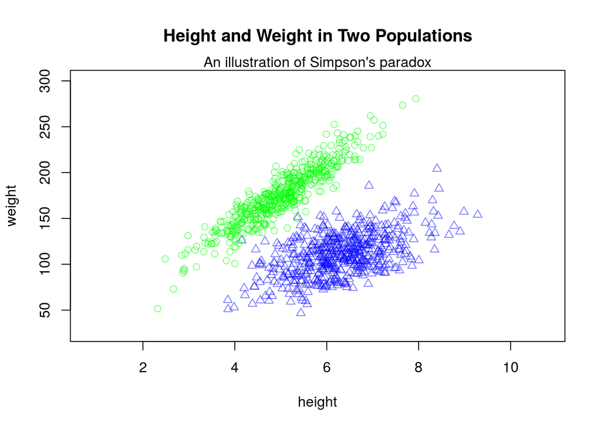

Source: http://www.r-bloggers.com/simpsons-paradox/

# Simpson's Paradox: A Demo (2)

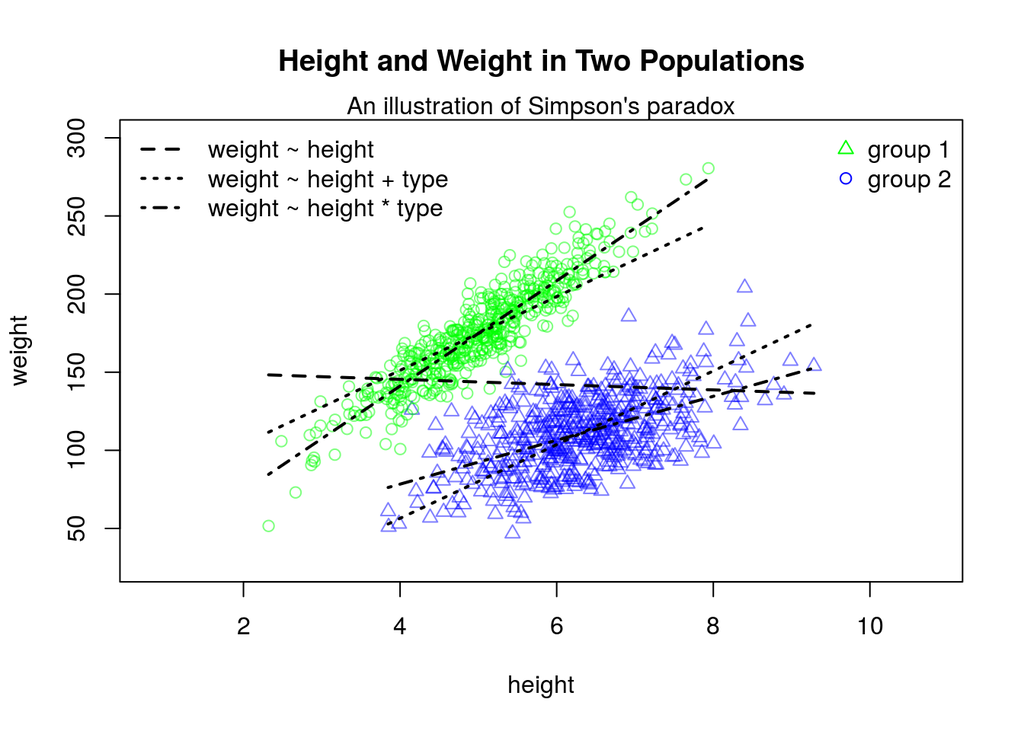

# Simpson's Paradox: A Demo (3)

|  | (1) | (2) | (3) |
| --- | --- | --- | --- |
| (Intercept) | 152.184 *** | 56.830 *** | 6.394 |
|  | (7.037) | (3.454) | (4.325) |
| height | -1.689 | 23.589 *** | 33.685 *** |
|  | (1.223) | (0.670) | (0.853) |
| typeblue |  | -94.726 *** | 15.736 * |
|  |  | (1.480) | (6.819) |
| height:typeblue |  |  | -19.630 *** |
|  |  |  | (1.189) |
| N | 1000 | 1000 | 1000 |
| R2 | 0.002 | 0.805 | 0.847 |
| logLik | -5172.425 | -4357.186 | -4236.252 |
| AIC | 10350.850 | 8722.372 | 8482.504 |
| *** p < 0.001; ** p < 0.01; * p < 0.05. |  |  |  |